# Chapter 10: Plotting and diagram visualization

*Matplotlib* is the most popular 2D plotting library in Python. Using matplotlib, you can create pretty much any type of plot.

*Pandas* has **tight integration** with *matplotlib*.

## How to install matplotlib?

If you have Anaconda installed, then matplotlib was already installed together with it.

If you have a standalone Python3 and Jupyter Notebook installation, open a command prompt / terminal and type in:

```
pip3 install matplotlib
```

## How to use matplotlib?

We will use the *pyplot module* inside the matlplotlib package for plotting. You can simply import this module as usual. It is usually aliased with the `plt` abbreviation:

```
import matplotlib.pyplot as plt
```

## The dataset

Let's use the *World Countries datatset*. For each country the following information is given:

1. country name,
2. region name,
3. population,
4. area (in mi<sup>2</sup>),
5. GDP (\$ per capita),
6. Literacy (%)

The dataset is given in the `data/countries_world.csv` file. The used delimiter is the semicolon (`;`) character.

```python
import pandas as pd
import matplotlib.pyplot as plt

# Special Jupyter Notebook command, so the plots by matplotlib will be display inside the Jupyter Notebook
%matplotlib inline

countries = pd.read_csv('../data/countries_world.csv', delimiter = ';')
countries.columns = ['country', 'region', 'population', 'area', 'gdp', 'literacy']
display(countries)
```

|  | country | region | population | area | gdp | literacy |
| --- | --- | --- | --- | --- | --- | --- |
| 0 | Afghanistan | ASIA (EX. NEAR EAST) | 31056997 | 647500 | 700.0 | 36.0 |
| 1 | Albania | EASTERN EUROPE | 3581655 | 28748 | 4500.0 | 86.5 |
| 2 | Algeria | NORTHERN AFRICA | 32930091 | 2381740 | 6000.0 | 70.0 |
| 3 | American Samoa | OCEANIA | 57794 | 199 | 8000.0 | 97.0 |
| 4 | Andorra | WESTERN EUROPE | 71201 | 468 | 19000.0 | 100.0 |
| ... | ... | ... | ... | ... | ... | ... |
| 222 | West Bank | NEAR EAST | 2460492 | 5860 | 800.0 | NaN |
| 223 | Western Sahara | NORTHERN AFRICA | 273008 | 266000 | NaN | NaN |
| 224 | Yemen | NEAR EAST | 21456188 | 527970 | 800.0 | 50.2 |
| 225 | Zambia | SUB-SAHARAN AFRICA | 11502010 | 752614 | 800.0 | 80.6 |
| 226 | Zimbabwe | SUB-SAHARAN AFRICA | 12236805 | 390580 | 1900.0 | 90.7 |

227 rows × 6 columns

*Data source: [US Government](https://gsociology.icaap.org/dataupload.html)*

Lets take just the top 50 countries by area, so visualization will be easier to overview in the following tasks:

```python
countries50 = countries.sort_values(by = 'area', ascending = False).head(50)
display(countries50)
```

|  | country | region | population | area | gdp | literacy |
| --- | --- | --- | --- | --- | --- | --- |
| 169 | Russia | C.W. OF IND. STATES | 142893540 | 17075200 | 8900.0 | 99.6 |
| 36 | Canada | NORTHERN AMERICA | 33098932 | 9984670 | 29800.0 | 97.0 |
| 214 | United States | NORTHERN AMERICA | 298444215 | 9631420 | 37800.0 | 97.0 |
| 42 | China | ASIA (EX. NEAR EAST) | 1313973713 | 9596960 | 5000.0 | 90.9 |
| 27 | Brazil | LATIN AMER. & CARIB | 188078227 | 8511965 | 7600.0 | 86.4 |
| ... | ... | ... | ... | ... | ... | ... |
| 124 | Madagascar | SUB-SAHARAN AFRICA | 18595469 | 587040 | 800.0 | 68.9 |
| 107 | Kenya | SUB-SAHARAN AFRICA | 34707817 | 582650 | 1000.0 | 85.1 |
| 69 | France | WESTERN EUROPE | 60876136 | 547030 | 27600.0 | 99.0 |
| 224 | Yemen | NEAR EAST | 21456188 | 527970 | 800.0 | 50.2 |
| 201 | Thailand | ASIA (EX. NEAR EAST) | 64631595 | 514000 | 7400.0 | 92.6 |

## Plotting

Plots can be generated with the `plot()` function of a Pandas *DataFrame* (table) or *Series* (column). The most important parameter of the function is the `kind` parameter, which defines the type of plot to be generated. Supported kinds are (non-exhaustive list):

- `line`
- `bar` (vertical bar)
- `barh` (horizontal bar)
- `scatter`
- `hist` (histogram)
- `box` (boxplot
- `pie`

After a plot is generated, it can be displayed by the `show()` function of the `matplotlib.pyplot` module.

### Vertical bar plot

Display a bar plot on the area of the selected 50 largest countries.

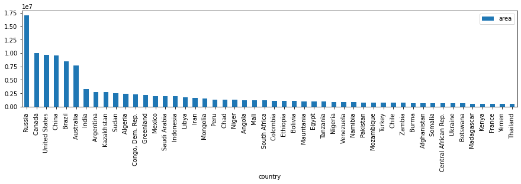

```python
countries50.plot(kind='bar', x='country', y='area', figsize = [15, 3])
plt.show() # matplotlib.pyplot was imported as plt
```

The size of the diagram can be configured with the `figsize` parameter. The size is given in inches (1 inch = 2.54 centimeters).  
The default size is `[6.4, 4.8]`.

The bar diagram can be created directly on the selected *Series* (column of data). In this case the Series will be placed along axis Y, while the horizontal axis X will become the index of the *DataFrame*.

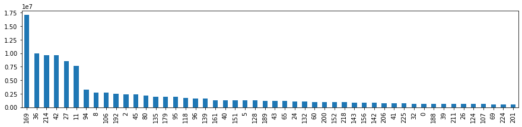

```python
countries50['area'].plot(kind='bar', figsize = [15, 3])
plt.show()
```

The index column can be modified through the `set_index` function (see Chapter 7 for more details) of the *DataFrame* and a **new** *DataFrame* is created so:

```python
countries50_indexed = countries50.set_index('country')
display(countries50_indexed)
```

| country | region | population | area | gdp | literacy |
| --- | --- | --- | --- | --- | --- |
| Russia | C.W. OF IND. STATES | 142893540 | 17075200 | 8900.0 | 99.6 |
| Canada | NORTHERN AMERICA | 33098932 | 9984670 | 29800.0 | 97.0 |
| United States | NORTHERN AMERICA | 298444215 | 9631420 | 37800.0 | 97.0 |
| China | ASIA (EX. NEAR EAST) | 1313973713 | 9596960 | 5000.0 | 90.9 |
| Brazil | LATIN AMER. & CARIB | 188078227 | 8511965 | 7600.0 | 86.4 |
| ... | ... | ... | ... | ... | ... |
| Madagascar | SUB-SAHARAN AFRICA | 18595469 | 587040 | 800.0 | 68.9 |
| Kenya | SUB-SAHARAN AFRICA | 34707817 | 582650 | 1000.0 | 85.1 |
| France | WESTERN EUROPE | 60876136 | 547030 | 27600.0 | 99.0 |
| Yemen | NEAR EAST | 21456188 | 527970 | 800.0 | 50.2 |
| Thailand | ASIA (EX. NEAR EAST) | 64631595 | 514000 | 7400.0 | 92.6 |

Creating the bar plot from the `countries50_indexed` *DataFrame* will display the country names as labels correctly.

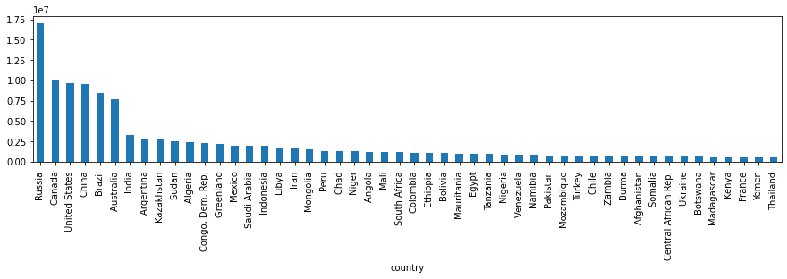

```python
countries50_indexed['area'].plot(kind='bar', figsize = [15, 3])
plt.show()
```

#### Visual tuning

The color of the bars can be defined with the `color` parameter. The width of the bars is set by the `width` parameter, 1.0 meaning *100%*.

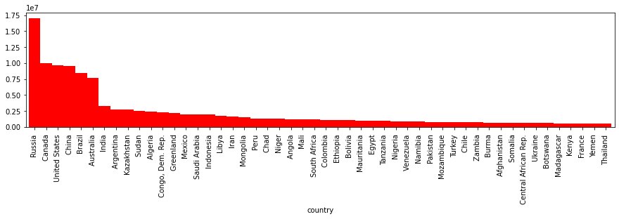

```python
countries50_indexed['area'].plot(kind='bar', figsize = [15, 3], color = 'red', width = 1.0)
plt.show()
```

Multiple colors can be passed in a list.

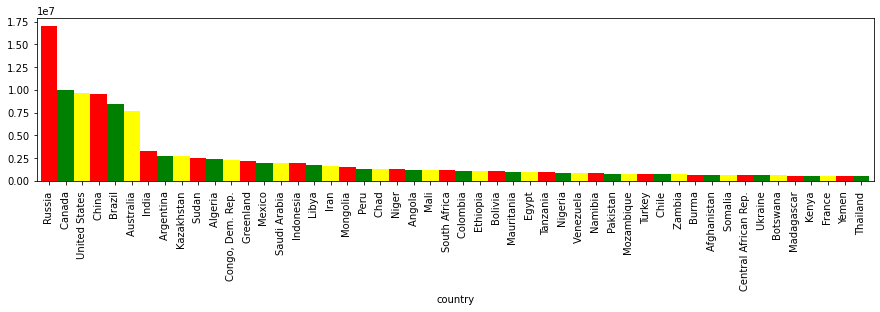

```python
countries50_indexed['area'].plot(kind='bar', figsize = [15, 3], color = ['red', 'green', 'yellow'], width = 1.0)
plt.show()
```

### Horizontal bar plot

Display a horizontal bar plot on the population of the selected 50 largest countries.

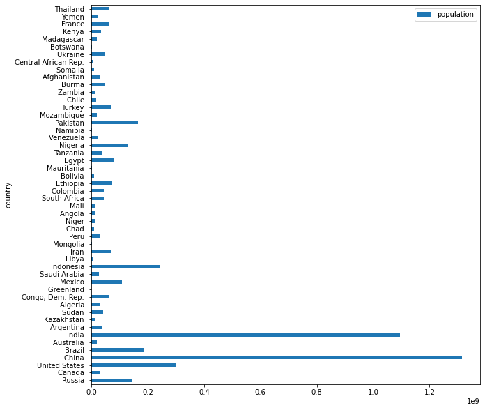

```python
countries50.plot(kind='barh', x='country', y='population', figsize = [10, 10])
plt.show()
```

Note that for the horizontal bar plot, the *axis X* is the vertical axis, and *axis Y* is the horizontal axis. It is defined by this was, so only the `kind` parameter of the `plot()` function has to be changed when switching to a different type of diagram.

Before visualizing the data, sort it by the column population, instead of the default area.

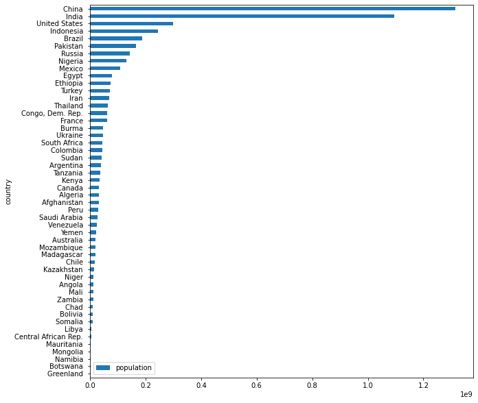

```python
countries50.sort_values(by = 'population').plot(kind='barh', x='country', y='population', figsize = [10, 10])
plt.show()
```

### Scatter plot

Display a scatter plot on the correlation of the area and the population columns of the selected 50 largest countries.

**Question:** What correlation can be expected between these 2 attributes of countries?

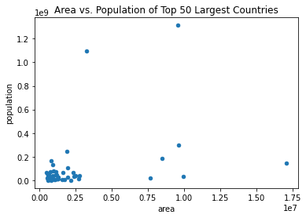

```python
countries50.plot(kind='scatter', x='area', y='population', title='Area vs. Population of Top 50 Largest Countries')
plt.show()
```

A title can be given to be displayed above the generated diagram with the `title` parameter.

Extend the scatter plot for all countries in the dataset.

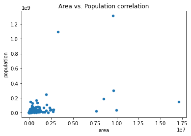

```python
countries.plot(kind='scatter', x='area', y='population', title='Area vs. Population correlation')
plt.show()
```

As we can observe there is a moderately strong correlation between area and population, which matches our expectation.

The limits of the X and Y axes can be configured with the `xlim` and `ylim` parameters, so the *outliers* can be excluded from the visualization. Both a minimum and a maximum boundary can be given, as a tuple.

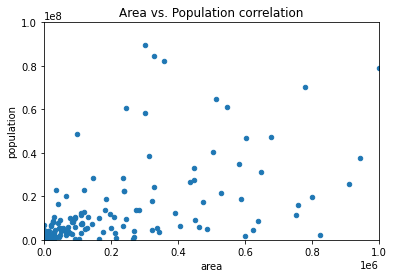

```python
countries.plot(kind='scatter', x='area', y='population', title='Area vs. Population correlation', xlim=(0, 1e6), ylim=(0, 1e8))
plt.show()
```

#### Short outlook on correlation *(optional)*

The correlation matrix between *Series* of a *Pandas DataFrame* can be generated with the `corr()` function:

```python
display(countries.corr())
```

|  | population | area | gdp | literacy |
| --- | --- | --- | --- | --- |
| population | 1.000000 | 0.469985 | -0.039324 | -0.043481 |
| area | 0.469985 | 1.000000 | 0.072185 | 0.035994 |
| gdp | -0.039324 | 0.072185 | 1.000000 | 0.513144 |
| literacy | -0.043481 | 0.035994 | 0.513144 | 1.000000 |

Or just for 2 selected Series:

```python
print(countries['area'].corr(countries['population']))
```

```
0.46998508371848174
```

Every correlation has two qualities: *strength* and *direction*. The direction of a correlation is either positive or negative. When two variables have a positive correlation, it means the variables move in the same direction. This means that as one variable increases, so does the other one. In a negative correlation, the variables move in inverse, or opposite, directions. In other words, as one variable increases, the other variable decreases.

We determine the strength of a relationship between two correlated variables by looking at the numbers. A correlation of 0 means that no relationship exists between the two variables, whereas a correlation of 1 indicates a perfect positive relationship. It is uncommon to find a perfect positive relationship in the real world.

The further away from 1 that a positive correlation lies, the weaker the correlation. Similarly, the further a negative correlation lies from -1, the weaker the correlation. The following guidelines are useful when determining the strength of a positive correlation:

- 1: perfect positive correlation
- .70 to .99: very strong positive relationship
- .40 to .69: strong positive relationship
- .30 to .39: moderate positive relationship
- .20 to .29: weak positive relationship
- .01 to .19: no or negligible relationship
- 0: no relationship exists

**Question:** which series of the dataframe show strong correlation?

### Histogram

A histogram is an accurate representation of the distribution of numerical data. It differs from a bar graph, in the sense that a bar graph relates two variables, but a histogram relates only one.

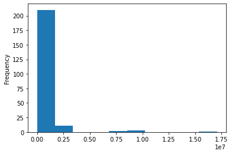

```python
countries['area'].plot(kind='hist')
plt.show()
```

The number of columns (called *bins* or *buckets*) in the histrogram can be configured with the `bins` parameter.

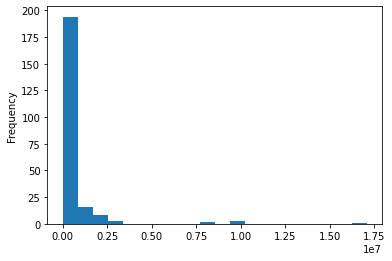

```python
countries['area'].plot(kind='hist', bins=20)
plt.show()
```

Extend the histogram to cover all countries in the dataset. Apply a logarithmic scale with the `logx` / `logy` parameter.

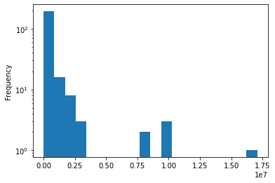

```python
countries['area'].plot(kind='hist', bins=20, logy=True)
plt.show()
```

### Boxplot

In descriptive statistics, a *boxplot* is a method for graphically depicting groups of numerical data through their quartiles.

Display a boxplot on the GDP of the selected 50 largest countries.

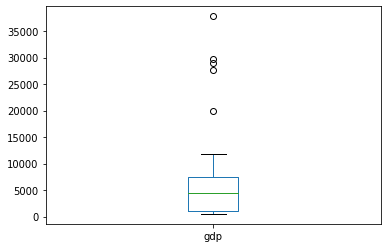

```python
countries50['gdp'].plot(kind='box')
plt.show()
```

Explaining the graphical visualization of a boxplot:

[figure not shown]

**Task:** Display a boxplot on the literacy of all countries! What can we state based on the diagram?

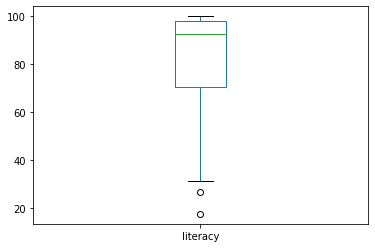

```python
countries['literacy'].plot(kind='box')
plt.show()
```

### Pie chart

Display a pie chart on the area share of the selected 50 largest countries. Since we are creating this plot on the `area` *Series*, we use the `countries50_indexed` DataFrame, which was indexed with the country names, so the labels will contain them instead of numerical indices.

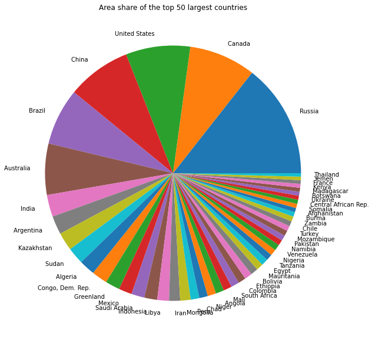

```python
countries50_indexed['area'].plot(kind='pie', figsize=[10,10], label="", title="Area share of the top 50 largest countries")
plt.show()
```

Percentages for each slice can be displayed with the `autopct` parameter:

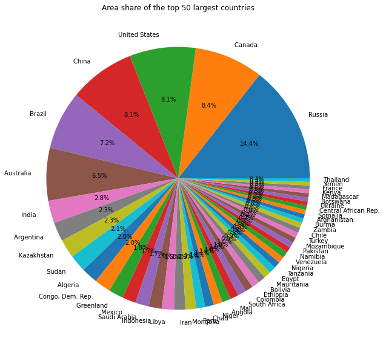

```python
countries50_indexed['area'].plot(kind='pie', figsize=[10,10], autopct='%.1f%%', label="", title="Area share of the top 50 largest countries")
plt.show()
```

### Saving a plot to file

Intead of using the `show()` function of the `matplotlib.pyplot` module, the `savefig()` function can also be used to export and save a created plot to an external file.

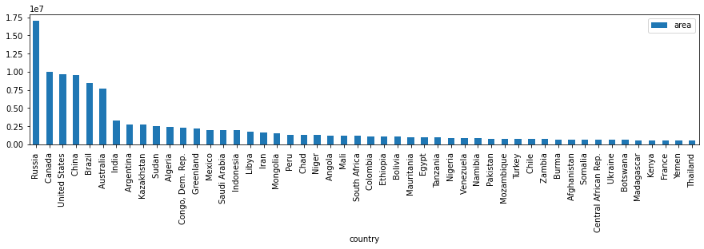

```python
countries50.plot(kind='bar', x='country', y='area', figsize = [15, 3])
plt.savefig('10_country_area.png')
```

Hint: look for the created file right next this Jupyter Notebook file on your computer.

## Time Series Analysis

Each row stores the following data:

1. location (country or region),
2. year,
3. male population,
4. female population,
5. total population,
6. population density.

The used delimiter is the semicolon (`;`) character.

```python
population_history = pd.read_csv('../data/population_history.csv', delimiter = ';')
display(population_history)
```

|  | Country | Year | PopMale | PopFemale | PopTotal | PopDensity |
| --- | --- | --- | --- | --- | --- | --- |
| 0 | Afghanistan | 1950 | 4099.243 | 3652.874 | 7752.117 | 11.874 |
| 1 | Afghanistan | 1951 | 4134.756 | 3705.395 | 7840.151 | 12.009 |
| 2 | Afghanistan | 1952 | 4174.450 | 3761.546 | 7935.996 | 12.156 |
| 3 | Afghanistan | 1953 | 4218.336 | 3821.348 | 8039.684 | 12.315 |
| 4 | Afghanistan | 1954 | 4266.484 | 3884.832 | 8151.316 | 12.486 |
| ... | ... | ... | ... | ... | ... | ... |
| 16725 | Zimbabwe | 2015 | 6568.778 | 7245.864 | 13814.642 | 35.711 |
| 16726 | Zimbabwe | 2016 | 6674.206 | 7356.132 | 14030.338 | 36.268 |
| 16727 | Zimbabwe | 2017 | 6777.054 | 7459.545 | 14236.599 | 36.801 |
| 16728 | Zimbabwe | 2018 | 6879.119 | 7559.693 | 14438.812 | 37.324 |
| 16729 | Zimbabwe | 2019 | 6983.353 | 7662.120 | 14645.473 | 37.858 |

16730 rows × 6 columns

*Data source: [United Nations](https://www.un.org/development/desa/pd/)*

Display the countries in the dataset:

```python
print(population_history['Country'].unique())
```

```
['Afghanistan' 'Albania' 'Algeria' 'American Samoa' 'Andean Community'
 'Andorra' 'Angola' 'Anguilla' 'Antigua and Barbuda' 'Argentina' 'Armenia'
 'Aruba' 'Australia' 'Australia/New Zealand' 'Austria' 'Azerbaijan'
 'Bahamas' 'Bahrain' 'Bangladesh' 'Barbados' 'Belarus' 'Belgium' 'Belize'
 'Benin' 'Bermuda' 'Bhutan' 'Bolivia (Plurinational State of)'
 'Bonaire, Sint Eustatius and Saba' 'Bosnia and Herzegovina' 'Botswana'
 'Brazil' 'British Virgin Islands' 'Brunei Darussalam' 'Bulgaria'
 'Burkina Faso' 'Burundi' "Côte d'Ivoire" 'Cabo Verde' 'Cambodia'
 'Cameroon' 'Canada' 'Cayman Islands' 'Central African Republic' 'Chad'
 'Channel Islands' 'Chile' 'China' 'China, Hong Kong SAR'
 'China, Macao SAR' 'China, Taiwan Province of China' 'Colombia' 'Comoros'
 'Congo' 'Cook Islands' 'Costa Rica' 'Croatia' 'Cuba' 'Curaçao' 'Cyprus'
 'Czechia' "Dem. People's Republic of Korea"
 'Democratic Republic of the Congo' 'Denmark' 'Djibouti' 'Dominica'
 'Dominican Republic' 'Ecuador' 'Egypt' 'El Salvador' 'Equatorial Guinea'
 'Eritrea' 'Estonia' 'Eswatini' 'Ethiopia' 'Falkland Islands (Malvinas)'
 'Faroe Islands' 'Fiji' 'Finland' 'France' 'French Guiana'
 'French Polynesia' 'Gabon' 'Gambia' 'Georgia' 'Germany' 'Ghana'
 'Gibraltar' 'Greece' 'Greenland' 'Grenada' 'Guadeloupe' 'Guam'
 'Guatemala' 'Guinea' 'Guinea-Bissau' 'Guyana' 'Haiti' 'Holy See'
 'Honduras' 'Hungary' 'Iceland' 'India' 'Indonesia'
 'Iran (Islamic Republic of)' 'Iraq' 'Ireland' 'Isle of Man' 'Israel'
 'Italy' 'Jamaica' 'Japan' 'Jordan' 'Kazakhstan' 'Kenya' 'Kiribati'
 'Kuwait' 'Kyrgyzstan' "Lao People's Democratic Republic" 'Latvia'
 'Lebanon' 'Lesotho' 'Liberia' 'Libya' 'Liechtenstein' 'Lithuania'
 'Luxembourg' 'Madagascar' 'Malawi' 'Malaysia' 'Maldives' 'Mali' 'Malta'
 'Marshall Islands' 'Martinique' 'Mauritania' 'Mauritius' 'Mayotte'
 'Melanesia' 'Mexico' 'Micronesia' 'Micronesia (Fed. States of)' 'Monaco'
 'Mongolia' 'Montenegro' 'Montserrat' 'Morocco' 'Mozambique' 'Myanmar'
 'Namibia' 'Nauru' 'Nepal' 'Netherlands' 'New Caledonia' 'New Zealand'
 'Nicaragua' 'Niger' 'Nigeria' 'Niue' 'North Macedonia'
 'Northern Mariana Islands' 'Norway' 'Oman' 'Pakistan' 'Palau' 'Panama'
 'Papua New Guinea' 'Paraguay' 'Peru' 'Philippines' 'Poland' 'Polynesia'
 'Portugal' 'Puerto Rico' 'Qatar' 'Réunion' 'Republic of Korea'
 'Republic of Moldova' 'Romania' 'Russian Federation' 'Rwanda'
 'Saint Barthélemy' 'Saint Helena' 'Saint Kitts and Nevis' 'Saint Lucia'
 'Saint Martin (French part)' 'Saint Pierre and Miquelon'
 'Saint Vincent and the Grenadines' 'Samoa' 'San Marino'
 'Sao Tome and Principe' 'Saudi Arabia' 'Senegal' 'Serbia' 'Seychelles'
 'Sierra Leone' 'Singapore' 'Sint Maarten (Dutch part)' 'Slovakia'
 'Slovenia' 'Solomon Islands' 'Somalia' 'South Sudan' 'Spain' 'Sri Lanka'
 'State of Palestine' 'Sudan' 'Suriname' 'Sweden' 'Switzerland'
 'Syrian Arab Republic' 'Tajikistan' 'Thailand' 'Timor-Leste' 'Togo'
 'Tokelau' 'Tonga' 'Trinidad and Tobago' 'Tunisia' 'Turkey' 'Turkmenistan'
 'Turks and Caicos Islands' 'Tuvalu' 'Uganda' 'Ukraine'
 'United Arab Emirates' 'United Kingdom' 'United Republic of Tanzania'
 'United States of America' 'United States Virgin Islands' 'Uruguay'
 'Uzbekistan' 'Vanuatu' 'Venezuela (Bolivarian Republic of)' 'Viet Nam'
 'Wallis and Futuna Islands' 'Western Sahara' 'Yemen' 'Zambia' 'Zimbabwe']
```

### Line plot

Line diagrams works best with a series of data, assuming continuous change between the known discrete values.  
Let's visualize the total and male population of *Hungary* between the years 1950 an 2019.

First filter the rows based on the country for *Hungary* and set the year as the index column.

```python
hungary = population_history[population_history['Country'] == 'Hungary']
hungary.set_index('Year', drop=False, inplace=True)
display(hungary)
```

| Year | Country | Year | PopMale | PopFemale | PopTotal | PopDensity |
| --- | --- | --- | --- | --- | --- | --- |
| 1950 | Hungary | 1950 | 4494.406 | 4843.312 | 9337.718 | 103.145 |
| 1951 | Hungary | 1951 | 4573.710 | 4906.897 | 9480.607 | 104.723 |
| 1952 | Hungary | 1952 | 4637.570 | 4960.372 | 9597.942 | 106.019 |
| 1953 | Hungary | 1953 | 4687.602 | 5005.300 | 9692.902 | 107.068 |
| 1954 | Hungary | 1954 | 4725.599 | 5043.080 | 9768.679 | 107.905 |
| ... | ... | ... | ... | ... | ... | ... |
| 2015 | Hungary | 2015 | 4646.716 | 5131.209 | 9777.925 | 108.008 |
| 2016 | Hungary | 2016 | 4636.375 | 5116.595 | 9752.970 | 107.732 |
| 2017 | Hungary | 2017 | 4626.816 | 5103.006 | 9729.822 | 107.476 |
| 2018 | Hungary | 2018 | 4617.623 | 5089.879 | 9707.502 | 107.230 |
| 2019 | Hungary | 2019 | 4608.250 | 5076.430 | 9684.680 | 106.978 |

70 rows × 6 columns

Now a line plot on the total population change of Hungary between 1950 and 2019 can be displayed.

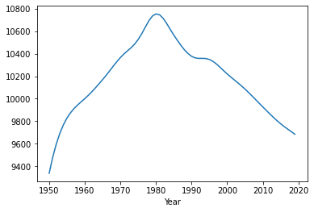

```python
hungary['PopTotal'].plot(kind='line')
plt.show()

# same:
#hungary.plot(kind='line', x='Year', y='PopTotal')
#plt.show()
```

### Multiple column diagrams

Let's use multiple columns in the previous line plot, and add the male population to the diagram as a second line.

Multiple plot data can be generated with the `plot()` method of Pandas *Series*. Calling the `show()` function of the `matplotlib.pyplot` module will visualize them on a single diagram.

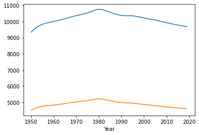

```python
hungary['PopTotal'].plot(kind='line')
hungary['PopMale'].plot(kind='line')
plt.show()
```

Add legend to the diagram:

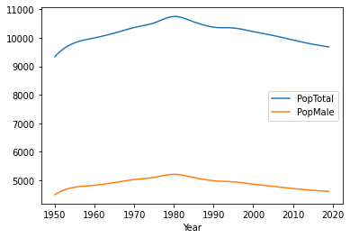

```python
hungary['PopTotal'].plot(kind='line', legend=True)
hungary['PopMale'].plot(kind='line', legend=True)
plt.show()
```

The same can be done by calling the `plot()` method of a *Pandas DataFrame*. Be aware though, that in this case each plot will be displayed in an individual diagram:

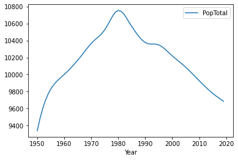

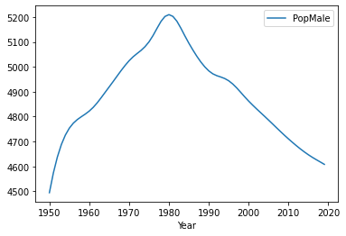

```python
hungary.plot(kind='line', x='Year', y='PopTotal', legend=True)
hungary.plot(kind='line', x='Year', y='PopMale', legend=True)
plt.show()
```

This can be fixed by explicitly configuring matplotlib to use the same *axis object* for visualization for both diagrams:

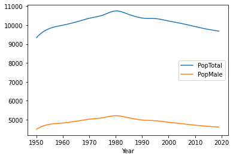

```python
ca = plt.gca() # gca = get current axis configuration object
hungary.plot(kind='line', x='Year', y='PopTotal', ax=ca, legend=True) # use the ca axis configuration object
hungary.plot(kind='line', x='Year', y='PopMale', ax=ca, legend=True) # use the ca axis configuration object
plt.show()
```

Use a different, secondary scale for the male population.

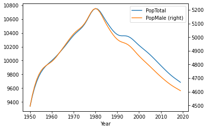

```python
hungary['PopTotal'].plot(kind='line', legend=True)
hungary['PopMale'].plot(kind='line', secondary_y=True, legend=True)
plt.show()
```

### Data grouping

*Pandas* supports the grouping of data by the given column(s), which then can be used also for visualization.

Select 10 countries by your choice.

```python
selected_countries = pd.Series(['Hungary', 'Germany', 'France', 'United Kingdom', 'Romania', 'Oman', 'Libya', 'Turkey', 'Chile', 'Viet Nam'])
display(selected_countries)
```

```
0           Hungary
1           Germany
2            France
3    United Kingdom
4           Romania
5              Oman
6             Libya
7            Turkey
8             Chile
9          Viet Nam
dtype: object
```

Select the rows of the original DataFrame for these selected countries.

```python
selected_history = population_history[population_history['Country'].isin(selected_countries)]
display(selected_history)
```

|  | Country | Year | PopMale | PopFemale | PopTotal | PopDensity |
| --- | --- | --- | --- | --- | --- | --- |
| 3150 | Chile | 1950 | 3335.670 | 3262.848 | 6598.518 | 8.875 |
| 3151 | Chile | 1951 | 3398.318 | 3331.262 | 6729.580 | 9.051 |
| 3152 | Chile | 1952 | 3465.497 | 3404.217 | 6869.714 | 9.239 |
| 3153 | Chile | 1953 | 3535.877 | 3480.588 | 7016.465 | 9.437 |
| 3154 | Chile | 1954 | 3608.433 | 3559.476 | 7167.909 | 9.640 |
| ... | ... | ... | ... | ... | ... | ... |
| 16375 | Viet Nam | 2015 | 46197.466 | 46479.616 | 92677.082 | 298.891 |
| 16376 | Viet Nam | 2016 | 46696.272 | 46944.163 | 93640.435 | 301.998 |
| 16377 | Viet Nam | 2017 | 47193.015 | 47407.628 | 94600.643 | 305.094 |
| 16378 | Viet Nam | 2018 | 47680.864 | 47865.095 | 95545.959 | 308.143 |
| 16379 | Viet Nam | 2019 | 48151.352 | 48310.756 | 96462.108 | 311.098 |

700 rows × 6 columns

The `selected_history` *DataFrame* now contains all historical data for the selected 10 countries.

Visualize the population change of the selected 10 countries for the time period 1950-2019 in a line diagram.  
To achieve this, we first group the `selected_history` *DataFrame* by the `Country` *Series*:

```python
selected_history.groupby('Country')
```

```
<pandas.core.groupby.generic.DataFrameGroupBy object at 0x7f148327a280>
```

We have got a `DataFrameGroupBy` object, which can be converted to a list:

```python
grouped_history = list(selected_history.groupby('Country'))
print("Length: {0}".format(len(grouped_history)))
```

```
Length: 10
```

Each item of the list contains all records for a given *country* (the column used for groupping):

```python
print(grouped_history[0])
```

```
('Chile',      Country  Year   PopMale  PopFemale   PopTotal  PopDensity
3150   Chile  1950  3335.670   3262.848   6598.518       8.875
3151   Chile  1951  3398.318   3331.262   6729.580       9.051
3152   Chile  1952  3465.497   3404.217   6869.714       9.239
3153   Chile  1953  3535.877   3480.588   7016.465       9.437
3154   Chile  1954  3608.433   3559.476   7167.909       9.640
...      ...   ...       ...        ...        ...         ...
3215   Chile  2015  8844.800   9124.556  17969.356      24.168
3216   Chile  2016  8965.258   9243.814  18209.072      24.490
3217   Chile  2017  9097.252   9373.183  18470.435      24.841
3218   Chile  2018  9228.416   9500.750  18729.166      25.189
3219   Chile  2019  9341.774   9610.261  18952.035      25.489

[70 rows x 6 columns])
```

**Question:** what happens if we group by the year column?

Based on the grouped *DataFrame*, we select the `PopTotal` *Series* and create a line plot. First the `Year` column is set as an index to be used for the X axis.

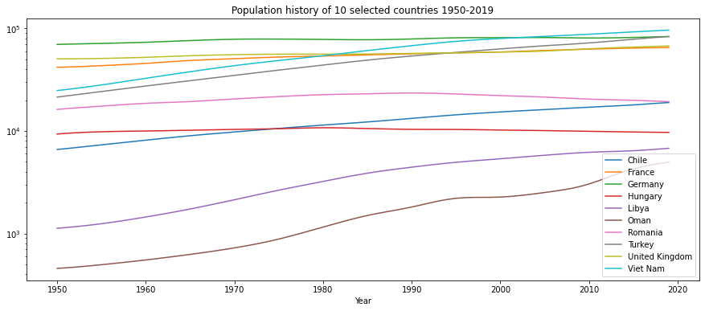

```python
selected_history.set_index('Year', inplace=True, drop=False)
selected_history.groupby('Country')['PopTotal'].plot(
    kind='line', logy=True,
    figsize=[15, 6], legend=True,
    title='Population history of 10 selected countries 1950-2019')
plt.show()
```

### Aggregate functions

Aggregate functions (`min`, `max`, `mean`, `median`, `sum`, etc.) transforms a group of values to a single value. By calling on aggregate function on a grouped *DataFrame*, the aggregated value of each group is calculated.

Let's calculate the largest population for each country they ever had between 1950 and 2019.

```python
population_history.groupby('Country').max()
```

| Country | Year | PopMale | PopFemale | PopTotal | PopDensity |
| --- | --- | --- | --- | --- | --- |
| Afghanistan | 2019 | 19529.727 | 18512.030 | 38041.757 | 58.269 |
| Albania | 2019 | 1682.757 | 1611.474 | 3286.070 | 119.930 |
| Algeria | 2019 | 21749.666 | 21303.388 | 43053.054 | 18.076 |
| American Samoa | 2019 | NaN | NaN | 59.684 | 298.420 |
| Andean Community | 2019 | 55331.532 | 56405.132 | 111736.664 | 30.027 |
| ... | ... | ... | ... | ... | ... |
| Wallis and Futuna Islands | 2019 | NaN | NaN | 15.098 | 107.843 |
| Western Sahara | 2019 | 304.755 | 277.703 | 582.458 | 2.190 |
| Yemen | 2019 | 14692.284 | 14469.638 | 29161.922 | 55.234 |
| Zambia | 2019 | 8843.214 | 9017.820 | 17861.034 | 24.026 |
| Zimbabwe | 2019 | 6983.353 | 7662.120 | 14645.473 | 37.858 |

239 rows × 5 columns

Sort the result by the `PopTotal` and only display the `PopTotal`:

```python
largest_pop = population_history.groupby('Country').max().sort_values(by = 'PopTotal')['PopTotal']
display(largest_pop)
```

```
Country
Holy See                             0.909
Tokelau                              1.953
Falkland Islands (Malvinas)          3.372
Niue                                 5.242
Saint Pierre and Miquelon            6.435
                                  ...
Pakistan                        216565.317
Indonesia                       270625.567
United States of America        329064.917
India                          1366417.756
China                          1433783.692
Name: PopTotal, Length: 239, dtype: float64
```

## Summary exercises on plotting

### Exercise 1

**Task:** Use the *World Countries dataset* defined in the `countries` variable. That dataset contained the *region* for each country. Compute for each region how many countries belong to them. Visualize the results in a pie a chart.

*Hint:* use groupping.

```python
countries_by_region = countries.groupby('region').count()['country']
display(countries_by_region)
```

```
region
ASIA (EX. NEAR EAST)                   28
BALTICS                                 3
C.W. OF IND. STATES                    12
EASTERN EUROPE                         12
LATIN AMER. & CARIB                    45
NEAR EAST                              16
NORTHERN AFRICA                         6
NORTHERN AMERICA                        5
OCEANIA                                21
SUB-SAHARAN AFRICA                     51
WESTERN EUROPE                         28
Name: country, dtype: int64
```

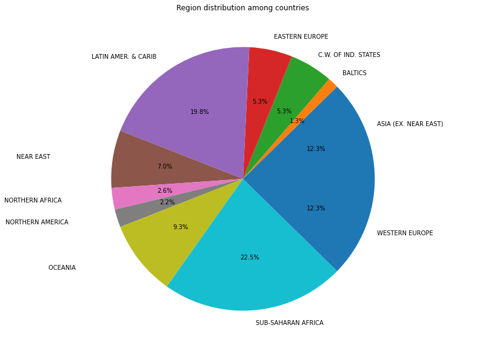

```python
countries_by_region.plot(kind='pie', figsize=[10,10], autopct='%.1f%%', label="",
                         title="Region distribution among countries")
plt.show()
```

### Exercise 2

**Task:** Calculate the accumulated population of the world for each year between 1950 and 2019 based on the *Population History dataset* stored in the `population_history` variable.  
Create a bar diagram visualizing how the aggregated population changed over the years.

```python
aggregated_by_year = population_history.groupby('Year').sum()
display(aggregated_by_year)
```

| Year | PopMale | PopFemale | PopTotal | PopDensity |
| --- | --- | --- | --- | --- |
| 1950 | 1278875.631 | 1282748.044 | 2562089.503 | 42672.546 |
| 1951 | 1303179.841 | 1306685.514 | 2610335.875 | 42728.190 |
| 1952 | 1327130.022 | 1330216.610 | 2657822.039 | 42972.585 |
| 1953 | 1351073.239 | 1353698.802 | 2705252.614 | 43345.374 |
| 1954 | 1375294.431 | 1377424.036 | 2753204.644 | 43831.847 |
| ... | ... | ... | ... | ... |
| 2015 | 3764759.824 | 3703476.149 | 7469342.451 | 106178.776 |
| 2016 | 3807875.525 | 3745887.267 | 7554873.938 | 107422.436 |
| 2017 | 3850938.612 | 3788132.946 | 7640187.980 | 108633.385 |
| 2018 | 3893745.012 | 3830090.171 | 7724957.236 | 109803.197 |
| 2019 | 3936030.563 | 3871616.311 | 7808774.650 | 110916.555 |

70 rows × 4 columns

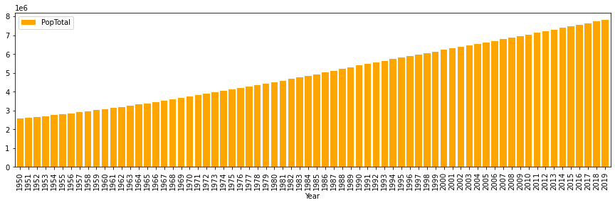

```python
aggregated_by_year.plot(kind='bar', y='PopTotal', figsize=[15, 4], width=0.8, color='orange')
plt.show()
```